# Tour of Job Scheduling in Python

## [`airflow`](https://airflow.apache.org/)

> Airflow is a platform to programmatically author, schedule and monitor workflows.
- airflow asks you to code you jobs into directed acyclic graphs (DAGs)
- with your jobs outlined into DAGs, you can pretty easily handle job dependencies and retry logic
- the airflow scheduler will automatically split out the workload across your server (or cluster or k8s pods)
- in addition, you get a web interface to monitor results and progress, quickly spot failures, manage environment variables, see code execution time trends, and visualize your DAGs

[figure not shown]

an airflow DAG is a python script

```python
from airflow import DAG
from airflow.operators.python_operator import PythonOperator
from datetime import datetime, timedelta
from my_cool_script import run_job

default_args = {
    'owner': 'me',
    'depends_on_past': False,
    'start_date': datetime(2018, 10, 11),
    'email': ['me@example.com'],
    'email_on_failure': True,
    'email_on_retry': False,
    'retries': 5,
    'retry_delay': timedelta(minutes=5),
}
```

```python
dag = DAG('my_cool_script', default_args=default_args,
    # schedule_interval = '*/15 9-17 * * *'
    # schedule_interval = timedelta(3600)
    schedule_interval = '@hourly')

run_job_task = PythonOperator(
    task_id = 'run-whole-job',
    python_callable = run_job,
    dag = dag)
```

What about running mulitple currency exchanges?

```python
with open('currencies.csv', 'r') as pair_file:
    pairs = pair_files.read().splitlines()

for pair in pairs:
    run_job_task = PythonOperator(
          task_id = f'process-{pair}',
          python_callable = run_job,
          op_args = [pair],
          dag=dag)
```

*could have also made the read file an upstream task*

**Pros**

- python (mostly / kind of)
- has simple + advanced scheduling syntax
- has awesome web UI
- easier to scale jobs up and elegantly handle complexity
- available on GCP as a managed service via [Cloud Composer](https://cloud.google.com/composer/)

**Cons**

- requires database for metadata and history (default is MySQL)
- requires much more administration and config than crontab
- learning curve of adapting to airflow philosophy

## [`AWS Lambda`](https://docs.aws.amazon.com/lambda/latest/dg/welcome.html)

`AWS Lambda` can be thought of as *Functions as a service*

Essentially, it’s a container that executes a small bit of work on AWS compute engines. However, you don’t need to worry about maintaining or launching those containers. Lamdba automatically starts up when your function is called.

Can be thought of as either a REST API model or cron job – enables and excels at both.

Has a limit of 15 minutes per task so have to keep your jobs small. However, you can use [AWS ECS](https://docs.aws.amazon.com/AmazonECS/latest/developerguide/scheduled_tasks.html) or [AWS Fargate](https://docs.aws.amazon.com/AmazonECS/latest/developerguide/scheduled_tasks.html) to run cron tasks instead of your jobs are too big for Lambda.

Adjusting code for AWS Lambda

```python
def lambda_handler(event=None, context=None):
    run_job()
```

handler function name can be whatever you want

```
event – AWS Lambda uses this parameter to pass in event data to the
handler. This parameter is usually of the Python dict type. It can
also be list, str, int, float, or NoneType type.

context – AWS Lambda uses this parameter to provide runtime
information to your handler. This parameter is of the LambdaContext
type.
```

Probably also want to [adjust your logging](https://docs.aws.amazon.com/lambda/latest/dg/python-logging.html), maybe even log as JSON format for AWS Cloudwatch monitoring that comes with Lambda.

Also can’t use sqlite as a database in Lambda, but super easy to swtich to AWS S3.

How to deploy python script to AWS Lambda

- create a virtualenv (or pipenv or conda env) and install all your dependencies in that environment
- zip up the entire directory of your installed dependencies from your virtual env + your code
  - do not zip the top directory, i.e. when the zip file gets unzipped Lambda needs to see everything and not need to `cd` into your package
  - [AWS has more detailed instructions if you need them](https://docs.aws.amazon.com/lambda/latest/dg/lambda-python-how-to-create-deployment-package.html)
- upload that zip file through AWS console or CLI
- from the Lambda function in AWS console or through AWS CLI, create a schedule to run using Cloudwatch

Example deploy using AWS CLI

```bash
aws lambda create-function \
--region us-east-2 \
--function-name GetCurrencyRate \
--zip-file fileb://my-cool-deployment-package.zip \
--role arn:aws:iam::account-id:role/lambda_basic_execution  \
--handler my_cool_script.lambda_handler \
--runtime python3.6 \
--timeout 300 \
--memory-size 512
```

[Step-by-step directions for AWS Console](https://www.fullstackpython.com/blog/aws-lambda-python-3-6.html)

Function created in AWS Console

[figure not shown]

Example of turning on [scheduled Cloudwatch trigger](https://www.kevinhooke.com/2018/03/27/running-aws-lambda-functions-on-a-timed-schedule/)

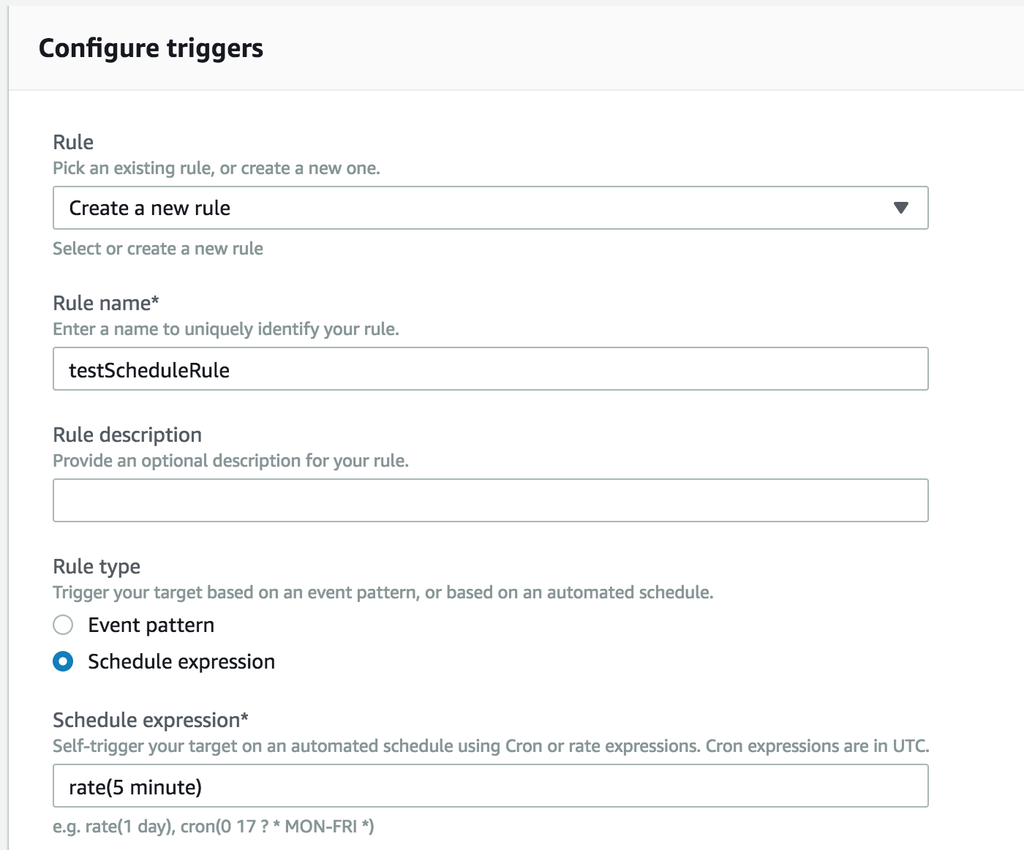

More [deploy](https://docs.aws.amazon.com/lambda/latest/dg/lambda-python-how-to-create-deployment-package.html) and [schedule](https://docs.aws.amazon.com/AmazonCloudWatch/latest/events/RunLambdaSchedule.html) documentation

Alternative ways to deploy that I like:

- [docker using `lambci/lambda:build-python3.6`](https://hub.docker.com/r/lambci/lambda/)
- [AWS SAM](https://docs.aws.amazon.com/lambda/latest/dg/serverless_app.html)
- [serverless](https://github.com/serverless/examples/tree/master/aws-python-scheduled-cron)

If you want dead simple and have freedom to pick your own AWS deploy tools, `serverless` is probably the choice you should make.

```bash
serverless deploy
```

**Pros**

- built in logging and monitoring through Cloudwatch
- no infrastructe/server management
- [dirt cheap for small tasks](https://aws.amazon.com/lambda/pricing/) – 1M free requests per month or ~2666 5 minute jobs at 512mb like example
- trivial to modify most simple scripts to work on Lambda

**Cons**

- have to be on AWS
- requires correct IAM roles & permissions (not always trivial)
- 15 minute runtime limit
- 512mb disk space limit so have to keep packages/dependencies/data small

## [`GCP Cloud Functions`](https://cloud.google.com/functions/docs/quickstart-console)

Google Cloud Functions are pretty much a mirror of AWS Lambda, except GCP is way easier to use IMHO

Except in this case…

GCP Cloud Functions doesn’t offer a scheduler!

Creating a work-around is not too horrible, but way more effort than should be necessary

- create a Google App Engine (GAE) app
- create a cron service for that app
- have cron tell the GAE app to send a request to Cloud Function using Pub/Sub as messenger

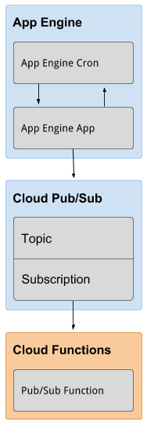

Why did I even bother telling you about GCP Cloud functions?

- deploy is crazy easy – paste python code, paste requirements.txt file, click deploy
- you can edit deployed function from console and it automatically creates version numbers for you
- monitoring, logs, and testing all available from function console page
- *GCP will probably add a cron like schedule at some point?*

[figure not shown]

[figure not shown]

## Quick decision matrix:

|  | AWS | GCP | On Premise |
| --- | --- | --- | --- |
| Small Data | Lambda | GAE / GCE | cron / schedule |
| Medium Data | ECS | GAE / GCE | celery |
| Big Data | Glue | Composer | airflow |

## Review and Final Thoughts

- Python is awesome
- Tooling for scheduled jobs in Python is diverse and excellent
- There’s tons of documentation and helpful articles online for everything I shared
- Options I didn’t cover, but are worth looking into:
  - python [`crontab`](https://pypi.org/project/python-crontab/) package
  - python [`croniter`](https://pypi.org/project/croniter/) package
  - python [Advanced Python Scheduler (`APScheduler`)](https://apscheduler.readthedocs.io/en/latest/) package